# Using functions with Data

Naomi Tague

January, 2020

# Comments/Questions on Error Checking

# Steps for running your model over multiple inputs

1. design a data structure to store results: sometimes this is automatic but not always
2. generate the input data
3. apply to the model

# Consider our function that estimates the power required to keep a car moving at a given speed

**Pb = crolling * m * g * V + 1/2 A * pair * cdrag * V3**

where *crolling* and *cdrag* are rolling and aerodynamic resistive coefficients, typical values are 0.015 and 0.3, respectively

*V*: is vehicle speed (assuming no headwind) in m/s (or mps) m: is vehicle mass in kg

*A* is surface area of car (m2)

*g* is acceleration due to gravity (9.8 m/s2) pair = density of air (1.2kg/m3)

*Pb* is power in Watts

# Code

```r
#' Power Required by Speed
#'
#' This function determines the power required to keep a vehicle moving at
#' a given speed
#' @param cdrag coefficient due to drag default=0.3
#' @param crolling coefficient due to rolling/friction default=0.015
#' @param v vehicle speed (m/2)
#' @param m vehicle mass (kg)
#' @param A area of front of vehicle (m2)
#' @param g acceleration due to gravity (m/s) default=9.8
#' @param pair (kg/m3) default =1.2
#' @return power (W)

autopower = function(V, m, A, cdrag=0.3, crolling=0.015,pair=1.2,g=9.8) {
  P = crolling*m*g*V + 1/2*A*pair*cdrag*V**3
  return(P)
}
```

I’ve also stored the autopower.R function as a file = using the recommended naming convention

**autopower.R**

# Generating data for the function and iterating over that data

Example use: Imagine we want to see how much power is generated given scenario where we know the mean and standard deviation of vehicles speeds

```r
source("Assignments/auto_power.R")
```

```
## Error in file(filename, "r", encoding = encoding): cannot open the connection
```

```r
# generate sample speeds from a distribution
nsample = 100
speeds = rnorm(mean=25, sd=4, n=nsample)

# Step 1  create data frame to store results
# how many simulations, what do you want to keep

#create a dataframe that has rows for each model run
# columns for height, flowrate and power estimate
results = data.frame(speed=speeds, power=NA)

head(results)
```

```
##      speed power
## 1 16.04470    NA
## 2 26.87146    NA
## 3 23.00649    NA
## 4 20.13741    NA
## 5 18.22709    NA
## 6 29.35418    NA
```

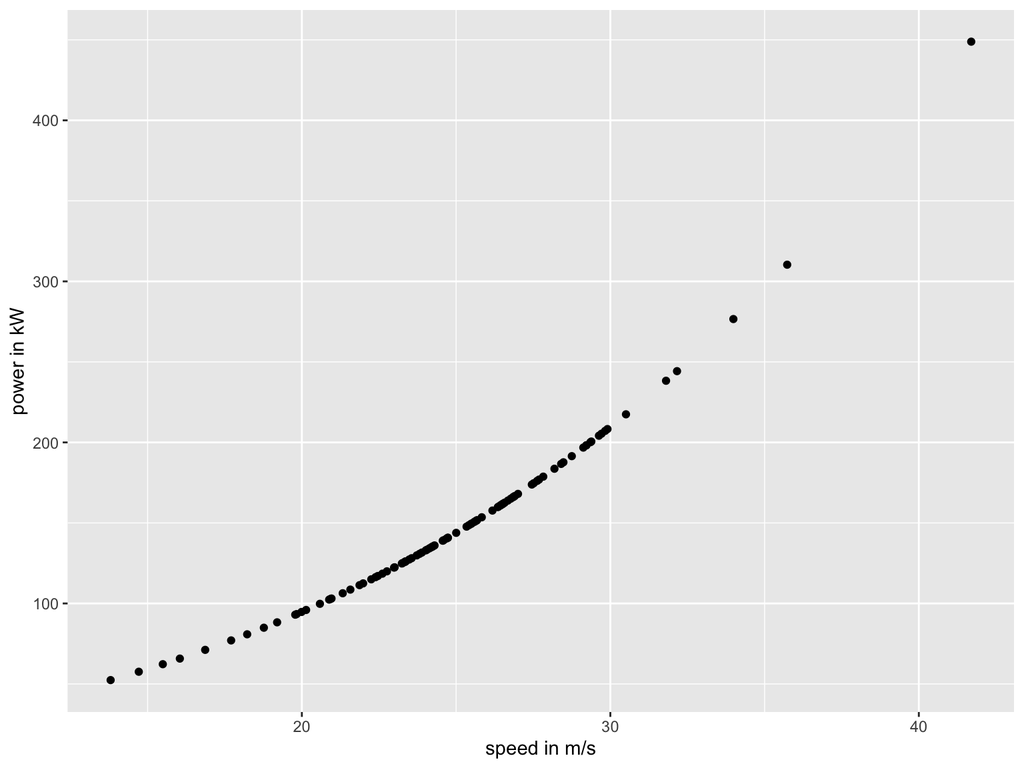

```r
# if you only have one input and everything else is the same, R is smart enough
# to create a set of outputs
results$power = autopower(V=speeds, A=25, m=20000)

# ALWAYS look at your results to make sure it make sense
ggplot(results, aes(speed, power/1000))+geom_point()+labs(x="speed in m/s", y="power in kW")
```

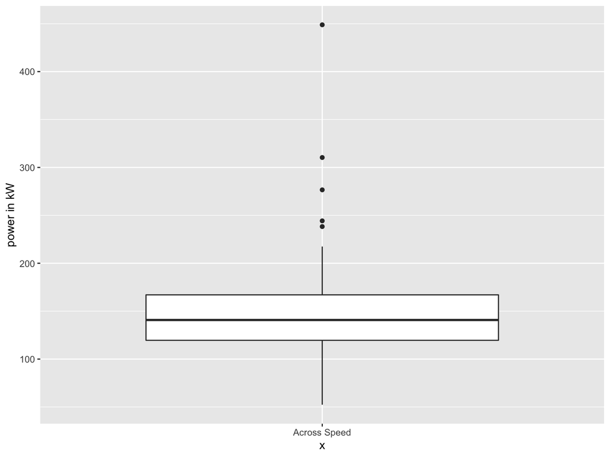

```r
ggplot(results, aes(x="Across Speed",y=power/1000))+geom_boxplot()+labs(y="power in kW")
```

# Looping (or repitition)

Looping is not always automatic * more complex scenarios - number of different values is not the same for all inputs * other programming languages

Lets start with the basics of how you do repetition in programming in general often called looping

```r
# repeat statement
a=0
for (i in 1:5) {
 a = a+i
}
a
```

```
## [1] 15
```

```r
# find the maximum speed
speeds = runif(min=0, max=100, n=300)

maxspeed=0
for ( i  in 1:length(speeds)) {
  maxspeed = ifelse(speeds[i] > maxspeed, speeds[i], maxspeed)
}

maxspeed
```

```
## [1] 99.89996
```

```r
max(speeds)
```

```
## [1] 99.89996
```

# A more complex example of looping in R

Lets **scale** up from a single car to a group of cars on a highway and use our **autopower** function to estimate a distribution of power

What might vary?

# Our highway

3 car types

Mean highway speed is 100 km/hr

```r
# generate a structure to store info on our possible cars
possible_cars = data.frame(name = c("A","B","C"),mass=c(10000,65000,38000), area = c(22,30,22))

# first look at how results vary for mean speed say 100km/hr
# do conversion
speed_base = 100 * 0.28

# because I have one mass and area for each car and only 1 speed
# I can estimate power for each car type
# add to the data structure
possible_cars$power = autopower(V=speed_base, A = possible_cars$area, m=possible_cars$mass)

head(possible_cars)
```

```
##   name  mass area    power
## 1    A 10000   22 128089.9
## 2    B 65000   30 386080.8
## 3    C 38000   22 243337.9
```

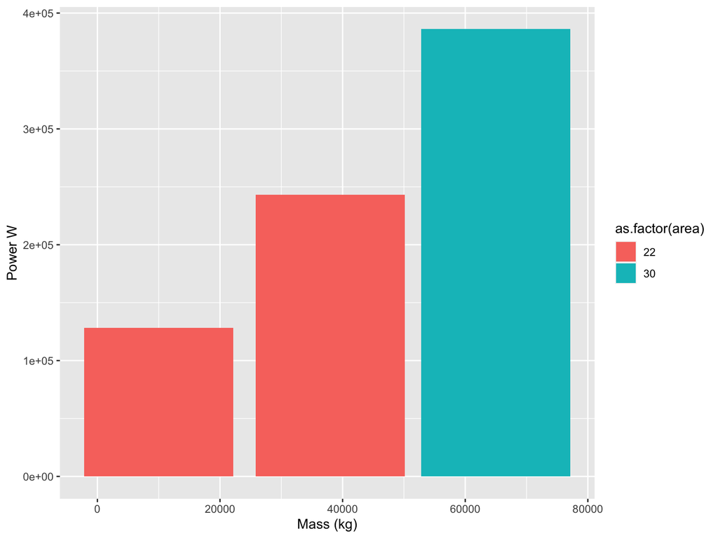

```r
# show results
ggplot(possible_cars, aes(x=mass, y=power, fill=as.factor(area)))+geom_col()+labs(y="Power W", x="Mass (kg)")
```

# Building a highway

What could be the total power consumed if there are 100 cars on this highway each hour, they are travelling at a range of speeds - mean is 100km/hr and speeds tend to be log-normally distributed)

How would the total power consumed vary by car So if all cars are car A; OR all cars are car B OR all cars are car C

- repeating by hand
- *pmap* for repetition - a efficient way of looping in R
- *for* for repetition - a more standard way of looping available in many langugaes

# First lets do it ‘by hand’

```r
# what is I want to estimate average power use given  each car

possible_cars
```

```
##   name  mass area    power
## 1    A 10000   22 128089.9
## 2    B 65000   30 386080.8
## 3    C 38000   22 243337.9
```

```r
# use sample to generate a distribution of speeds

# assume a log normal distribution of speeds with mean 100km/hr
# recall our function needs speed in m/s not km/hr so we will also do a conversion
# lets get a sample of a 200 speeds- we could also do this by actually measuring speeds

nsample = 200
mean_speed = log(100*0.277)

speeds = rlnorm(mean=mean_speed, sd=0.1*mean_speed, nsample)
summary(speeds)
```

```
##    Min. 1st Qu.  Median    Mean 3rd Qu.    Max.
##   12.47   22.52   26.74   28.99   33.21   68.46
```

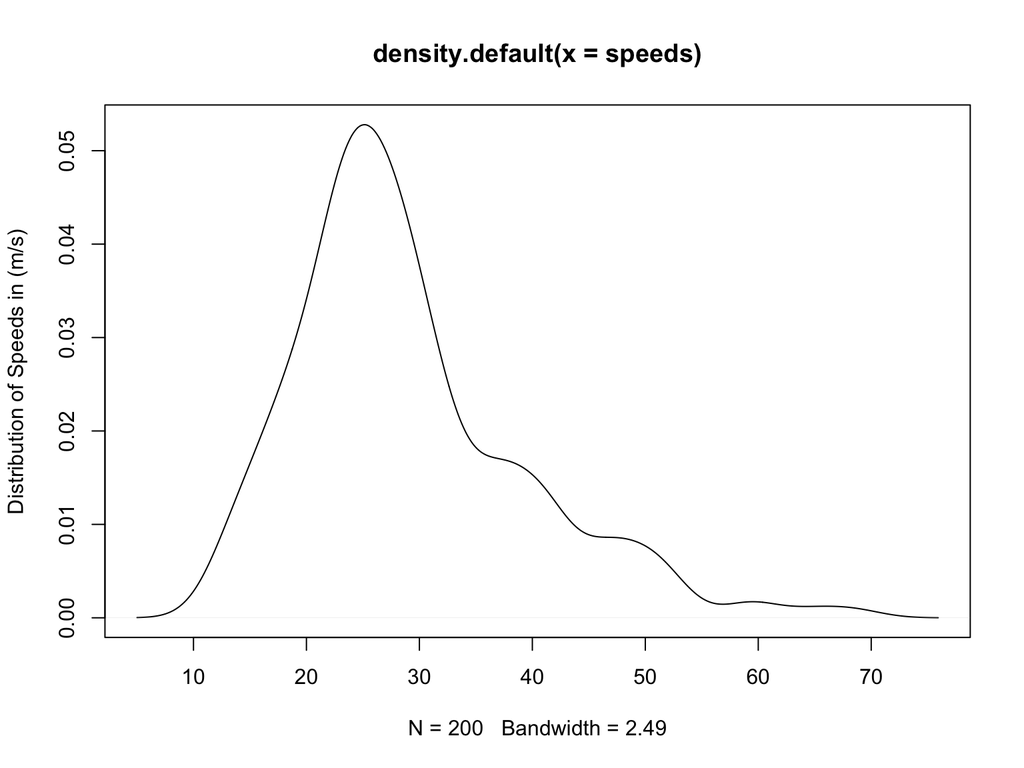

```r
plot(density(speeds), ylab="Distribution of Speeds in (m/s)")
```

```r
# how do we run each car for all speeds

# first lets to it by hand for the first car - the first row in our possible cars matrix
possible_cars[1,]
```

```
##   name  mass area    power
## 1    A 10000   22 128089.9
```

```r
# we could do it by hand
powerA = autopower(V=speeds, A = possible_cars$area[1], m=possible_cars$mass[1])
# lets look at what we get
summary(powerA)
```

```
##    Min. 1st Qu.  Median    Mean 3rd Qu.    Max.
##   26016   78296  115059  179696  193929 1371138
```

```r
# next car (row 2)
powerB = autopower(V=speeds, A = possible_cars$area[2], m=possible_cars$mass[2])
# lets look at what we get
summary(powerB)
```

```
##    Min. 1st Qu.  Median    Mean 3rd Qu.    Max.
##  129643  276768  358818  463929  515233 2386626
```

```r
# next car (row 3)
powerC = autopower(V=speeds, A = possible_cars$area[3], m=possible_cars$mass[3])
# lets look at what we get
summary(powerC)
```

```
##    Min. 1st Qu.  Median    Mean 3rd Qu.    Max.
##   77349  170969  225132  299020  330640 1652913
```

```r
# we could put this together
powerall1 = cbind.data.frame(powerA, powerB, powerC)
colnames(powerall1)=possible_cars$name


# for plotting sometimes its useful to turn columns in to rows
powerallr1 = powerall1 %>% pivot_longer(cols=everything(), names_to="car", values_to="power")
head(powerallr1)
```

```
## # A tibble: 6 x 2
##   car     power
##   <chr>   <dbl>
## 1 A     141182.
## 2 B     412776.
## 3 C     261250.
## 4 A     107711.
## 5 B     343104.
## 6 C     214680.
```

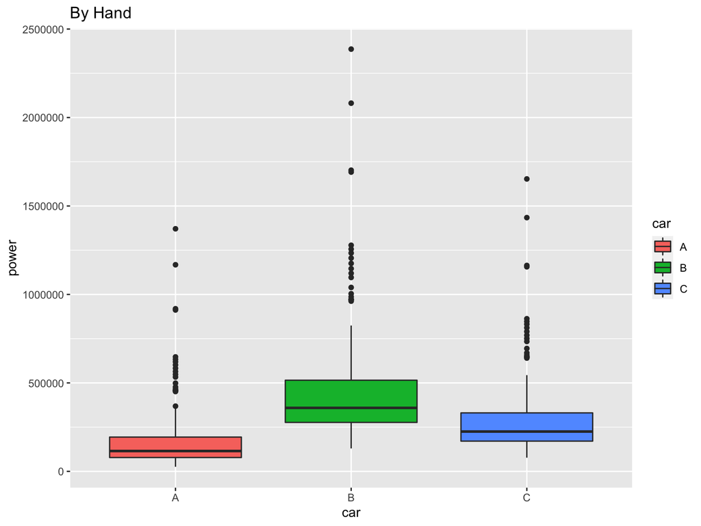

```r
# quick visualization
# lets save it so that we can compare
method1_plot = ggplot(powerallr1, aes(car,power, fill=car))+geom_boxplot()+ggtitle("By Hand")
method1_plot
```

# Second using R built in tools

Doing this by hand would be hard if we had many different cars - can we automate?

YES

first lets try *pmap*

*pmap* is available in the *purr* library

*mapply* is another R option

```r
# the first part, generating speeds is the same
# what is I want to estimate average power use given  each car

possible_cars
```

```
##   name  mass area    power
## 1    A 10000   22 128089.9
## 2    B 65000   30 386080.8
## 3    C 38000   22 243337.9
```

```r
# the first part is the same as above
# use sample to generate a distribution of speeds

# assume a log normal distribution of speeds with mean 100km/hr
# recall our function needs speed in m/s not km/hr so we will also do a conversion
# lets get a sample of a 200 speeds- we could also do this by actually measuring speeds

nsample = 200
mean_speed = log(100*0.277)

speeds = rlnorm(mean=mean_speed, sd=0.1*mean_speed, nsample)
summary(speeds)
```

```
##    Min. 1st Qu.  Median    Mean 3rd Qu.    Max.
##   11.15   23.11   28.77   29.38   34.28   53.88
```

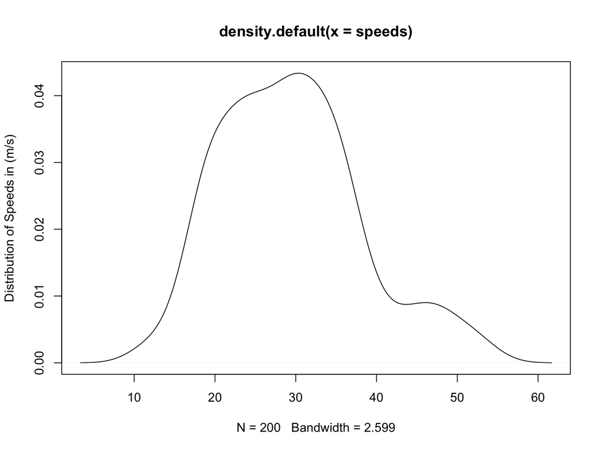

```r
plot(density(speeds), ylab="Distribution of Speeds in (m/s)")
```

```r
# how do we run each car for all speeds
# pmap runs a function for each value in a list of parameters, with other parameters set for each iteration


powerall2 = pmap(list(A = possible_cars$area, m=possible_cars$mass), autopower, V=speeds)

# lets turn to a data frame for easier graphing
# we can add column names
powerall2 = as.data.frame(powerall2, col.names=possible_cars$name)

# apply family of functions does this to - FYI
# what mapply does is run the function for each row in parameters listed, using values for other parameters listed in MoreArgs EACH time - a column for row in parameter list is returned
powerall2b = mapply(FUN=autopower, A = possible_cars$area, m=possible_cars$mass, MoreArgs = list(V=speeds)  )
# we can add column names
colnames(powerall2b)=possible_cars$name

head(powerall2b)
```

```
##              A         B        C
## [1,] 492843.78 1030336.9 688152.4
## [2,] 132012.82  394146.6 248741.6
## [3,]  69655.08  255892.8 157371.6
## [4,] 136776.71  403863.2 255261.0
## [5,] 229808.71  581626.7 376041.2
## [6,]  53614.39  214612.5 130751.7
```

```r
head(powerall2)
```

```
##           A         B        C
## 1 492843.78 1030336.9 688152.4
## 2 132012.82  394146.6 248741.6
## 3  69655.08  255892.8 157371.6
## 4 136776.71  403863.2 255261.0
## 5 229808.71  581626.7 376041.2
## 6  53614.39  214612.5 130751.7
```

```r
# for plotting sometimes its useful to turn columns in to rows
powerallr2 = powerall2 %>% pivot_longer(cols=everything(), names_to="car", values_to="power")
head(powerallr2)
```

```
## # A tibble: 6 x 2
##   car      power
##   <chr>    <dbl>
## 1 A      492844.
## 2 B     1030337.
## 3 C      688152.
## 4 A      132013.
## 5 B      394147.
## 6 C      248742.
```

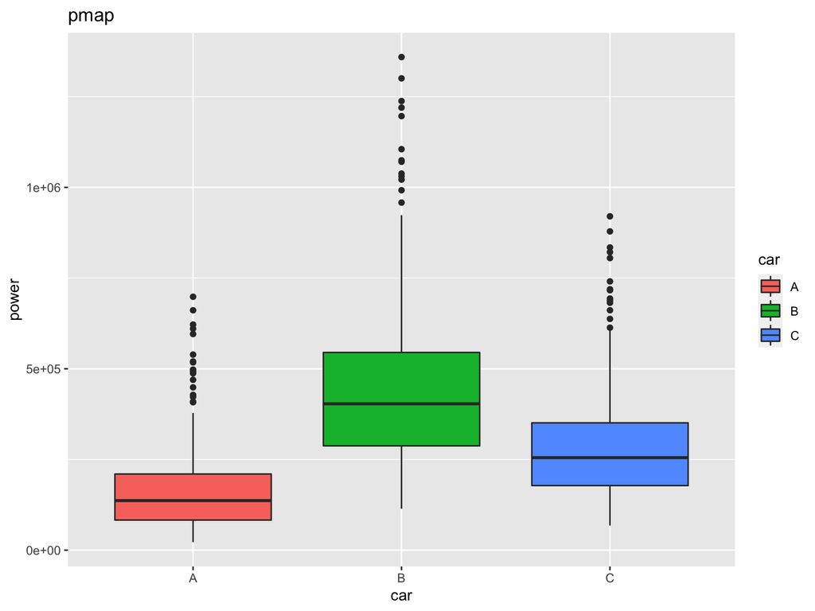

```r
# quick visualization

method2_plot = ggplot(powerallr2, aes(car,power, fill=car))+geom_boxplot()+ggtitle("pmap")
method2_plot
```

```r
# put plots side by side
# to confirm that they look similar
ggarrange(method1_plot, method2_plot)
```

[output not shown]

```
## Error in ggarrange(method1_plot, method2_plot): could not find function "ggarrange"
```

```r
# compare values
head(powerallr2)
```

```
## # A tibble: 6 x 2
##   car      power
##   <chr>    <dbl>
## 1 A      492844.
## 2 B     1030337.
## 3 C      688152.
## 4 A      132013.
## 5 B      394147.
## 6 C      248742.
```

```r
head(powerallr1)
```

```
## # A tibble: 6 x 2
##   car     power
##   <chr>   <dbl>
## 1 A     141182.
## 2 B     412776.
## 3 C     261250.
## 4 A     107711.
## 5 B     343104.
## 6 C     214680.
```

```r
# not exactly the same - why?
# recall that we sample speeds!

# but we can compare means (also using  map :)
# map runs the function (here - mean), over each column
# they are close but still not exact, so statistics such as means and quantiles are # similar, and relative difference between cars is the same
powerall1 %>% map(mean)
```

```
## $A
## [1] 179695.9
##
## $B
## [1] 463929.1
##
## $C
## [1] 299019.6
```

```r
powerall2 %>% map(mean)
```

```
## $A
## [1] 171589.4
##
## $B
## [1] 455846.1
##
## $C
## [1] 292532.9
```

```r
# upper 90% quantile
powerall1 %>% map(quantile, probs=0.9)
```

```
## $A
##      90%
## 367281.6
##
## $B
##      90%
## 822000.8
##
## $C
##      90%
## 542357.7
```

```r
powerall2 %>% map(quantile, probs=0.9)
```

```
## $A
##      90%
## 341658.1
##
## $B
##      90%
## 778419.2
##
## $C
##    90%
## 512024
```

# Third - classic looping *for*

*pmap* works quickly but it is unique to R Other programming language (and R) use what are called loops - where repetition is more explicit

Lets do this one more time using a *for* loop

```r
# the first part, generating speeds is the same
# what is I want to estimate average power use given  each car

possible_cars
```

```
##   name  mass area    power
## 1    A 10000   22 128089.9
## 2    B 65000   30 386080.8
## 3    C 38000   22 243337.9
```

```r
# use sample to generate a distribution of speeds

# assume a log normal distribution of speeds with mean 100km/hr
# recall our function needs speed in m/s not km/hr so we will also do a conversion
# lets get a sample of a 200 speeds- we could also do this by actually measuring speeds

nsample = 200
mean_speed = log(100*0.277)

speeds = rlnorm(mean=mean_speed, sd=0.1*mean_speed, nsample)
summary(speeds)
```

```
##    Min. 1st Qu.  Median    Mean 3rd Qu.    Max.
##   11.67   21.54   26.47   28.45   34.39   67.89
```

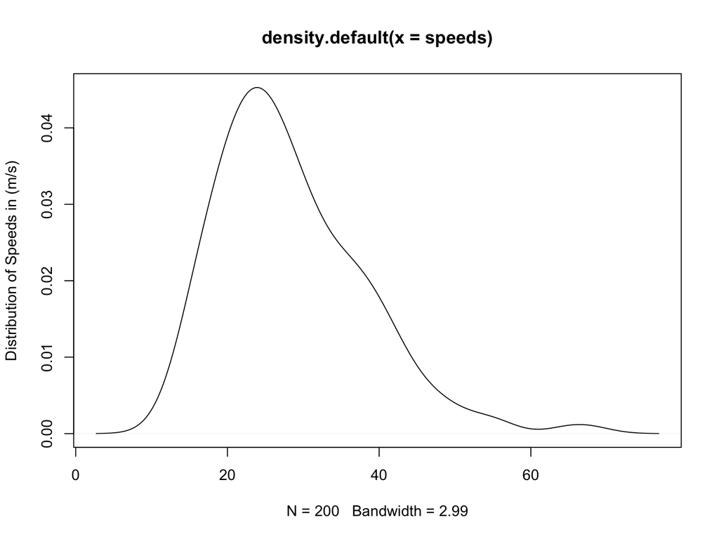

```r
plot(density(speeds), ylab="Distribution of Speeds in (m/s)")
```

```r
# how do we run each car for all speeds
# we use a for loop to cycle through
# we need to create a data frame to store results - as above
# one column for each car and one row for each speed

powerall3 = as.data.frame(matrix(nrow=length(speeds), ncol=nrow(possible_cars)))
# because we don't initialize it - values are NA
head(powerall3)
```

```
##   V1 V2 V3
## 1 NA NA NA
## 2 NA NA NA
## 3 NA NA NA
## 4 NA NA NA
## 5 NA NA NA
## 6 NA NA NA
```

```r
# how many cars area there
nrow(possible_cars)
```

```
## [1] 3
```

```r
# for loops use an index - in this case "i" but you could use anything - it repeats
# anything between the {} for each values of i between 1 and nrow(possible_car) (which is 3 in our case)

# index in to a matrix (like powerall3) is by row and column powerall3[2,5] is 2nd row and 5th column
for (i in 1:nrow(possible_cars)) {
  powerall3[,i] = autopower(A=possible_cars$area[i], m=possible_cars$mass[i], V=speeds)
}

# now it looks like above
head(powerall3)
```

```
##          V1       V2       V3
## 1  89973.23 303856.4 188732.6
## 2 112248.66 352844.9 221154.5
## 3 327001.50 753283.4 494560.2
## 4  38287.85 170553.6 102800.5
## 5 128547.19 387024.1 243969.5
## 6  58267.15 226990.3 138693.4
```

```r
# we can add column names
colnames(powerall3)=possible_cars$name

# plotting is the same as above

# for plotting sometimes its useful to turn columns in to rows
powerallr3 = powerall3 %>% pivot_longer(cols=everything(), names_to="car", values_to="power")
head(powerallr3)
```

```
## # A tibble: 6 x 2
##   car     power
##   <chr>   <dbl>
## 1 A      89973.
## 2 B     303856.
## 3 C     188733.
## 4 A     112249.
## 5 B     352845.
## 6 C     221154.
```

```r
# quick visualization
method3_plot = ggplot(powerallr3, aes(car,power, fill=car))+geom_boxplot()+ggtitle("For Loop")

ggarrange(method1_plot, method2_plot, method3_plot, nrow=3)
```

[output not shown]

```
## Error in ggarrange(method1_plot, method2_plot, method3_plot, nrow = 3): could not find function "ggarrange"
```

```r
powerall1 %>% map(mean)
```

```
## $A
## [1] 179695.9
##
## $B
## [1] 463929.1
##
## $C
## [1] 299019.6
```

```r
powerall2 %>% map(mean)
```

```
## $A
## [1] 171589.4
##
## $B
## [1] 455846.1
##
## $C
## [1] 292532.9
```

```r
powerall3 %>% map(mean)
```

```
## $A
## [1] 168567.7
##
## $B
## [1] 444687
##
## $C
## [1] 285674.2
```

# Steps for running function over multiple inputs

1. design a data structure to store results: sometimes this is automatic but not always
2. generate the data (or read it in)
3. find ways to repeat things efficiently
- *purr* family of function in R
- more generally looping (*for*, *while*, …others)

# Assignment 2b

Working in the groups that you used for assignment 2b - and your existing autopower function;

- add some error checking to your function; save in its own file as usual
- In an Rmarkdown document, using the cars that I generated in class (see Class4_Using_functions_with_data.Rmd on Gauchospace),
- recreate *possible_cars*, add an additional car with mass 30,000 kg, surface area 10m2
- create a random sample of 100 highways each with a different rolling coefficient; , sample the rolling coefficients from a uniform distribution with a minimum value of 0.01 and a maximum value of 0.03, sample 100 different highways
- use a *for* loop to compute the power for each of 100 different highways for each car in *possible_cars* - for all calculations consider only a single speed - 120 km/hr. We are assuming this is the average speed driven on all highways
- create a box plot of power consumed for each car type (where the boxes will show ranges across the different highways)
- use *pmap* to repeat your calculations and create a second boxplot

Submit the github link as usual on Gauchospace